# MT5763_2_230012908

Anastasia Akchurina

2023-10-16

https://github.com/mt5763standrews/individual-assignment-2-AnastasiaStAndrews

# Assignment 2

```r
library(tidyverse)
```

## Data wrangling - Bike Seoul

```r
BikeSeoul <- read_csv("~/BikeSeoul.csv") %>%
  select(-c(7, 8, 9, 10, 11)) %>%
  rename(
    Date = Date,
    Count = 'Rented Bike Count',
    Hour = Hour,
    Temperature = 'Temperature(C)',
    Humidity = 'Humidity(%)',
    WindSpeed = 'Wind speed (m/s)',
    Season = Seasons,
    Holiday = Holiday,
    FunctioningDay = 'Functioning Day'
  ) %>%
  filter(FunctioningDay == 'Yes') %>%
  select(-FunctioningDay) %>%
  mutate(Date = as.Date(Date, format = '%d/%m/%Y'),
         FullDate = make_datetime(year(Date), month(Date), day(Date), hour = Hour, min = 0, sec = 0),
         Holiday = factor(ifelse(Holiday == "Holiday", "Yes", "No"), levels = c('Yes', 'No')),
         Season = factor(Season, levels = c('Spring', 'Summer', 'Autumn', 'Winter')))
BikeSeoul
```

```
## # A tibble: 8,465 × 9
##    Date       Count  Hour Temperature Humidity WindSpeed Season Holiday
##    <date>     <dbl> <dbl>       <dbl>    <dbl>     <dbl> <fct>  <fct>
##  1 2017-12-01   254     0        -5.2       37       2.2 Winter No
##  2 2017-12-01   204     1        -5.5       38       0.8 Winter No
##  3 2017-12-01   173     2        -6         39       1   Winter No
##  4 2017-12-01   107     3        -6.2       40       0.9 Winter No
##  5 2017-12-01    78     4        -6         36       2.3 Winter No
##  6 2017-12-01   100     5        -6.4       37       1.5 Winter No
##  7 2017-12-01   181     6        -6.6       35       1.3 Winter No
##  8 2017-12-01   460     7        -7.4       38       0.9 Winter No
##  9 2017-12-01   930     8        -7.6       37       1.1 Winter No
## 10 2017-12-01   490     9        -6.5       27       0.5 Winter No
## # ℹ 8,455 more rows
## # ℹ 1 more variable: FullDate <dttm>
```

## Data wrangling - Bike Washington DC

```r
BikeWashingtonDC <- read_csv("~/BikeWashingtonDC.csv") %>%
  select(-c(1, 4, 5, 8, 9, 10, 12, 15, 16)) %>%
  rename(
    Date = dteday,
    Season = season,
    Hour = hr,
    Holiday = holiday,
    Temperature = temp,
    Humidity = hum,
    WindSpeed = windspeed,
    Count = cnt
  ) %>%
  mutate(
    Humidity = Humidity * 100,
    Temperature = (Temperature * (39 + 8)) - 8,
    WindSpeed = WindSpeed * 67 * 1000/3600,
    Holiday = factor(ifelse(Holiday == 1, "Yes", "No"), levels = c('Yes', 'No')),
    Date = as.Date(Date, format = '%d/%m/%Y'),
    FullDate = make_datetime(year(Date), month(Date), day(Date), hour = Hour, min = 0, sec = 0)
  ) %>%
  mutate(
    Season = factor(Season, levels = c('2', '3', '4', '1')),
    Season = recode(Season, '2' = 'Spring', '3' = 'Summer', '4' = 'Autumn', '1' = 'Winter')
  ) %>%
  mutate(Season = factor(Season, levels = c('Spring', 'Summer', 'Autumn', 'Winter')))
BikeWashingtonDC
```

```
## # A tibble: 17,379 × 9
##    Date       Season  Hour Holiday Temperature Humidity WindSpeed Count
##    <date>     <fct>  <dbl> <fct>         <dbl>    <dbl>     <dbl> <dbl>
##  1 2011-01-01 Winter     0 No             3.28       81      0       16
##  2 2011-01-01 Winter     1 No             2.34       80      0       40
##  3 2011-01-01 Winter     2 No             2.34       80      0       32
##  4 2011-01-01 Winter     3 No             3.28       75      0       13
##  5 2011-01-01 Winter     4 No             3.28       75      0        1
##  6 2011-01-01 Winter     5 No             3.28       75      1.67     1
##  7 2011-01-01 Winter     6 No             2.34       80      0        2
##  8 2011-01-01 Winter     7 No             1.4        86      0        3
##  9 2011-01-01 Winter     8 No             3.28       75      0        8
## 10 2011-01-01 Winter     9 No             7.04       76      0       14
## # ℹ 17,369 more rows
## # ℹ 1 more variable: FullDate <dttm>
```

### Checking the data wrangling results for Seoul and Washington data

```r
colnames(BikeSeoul)
```

```
## [1] "Date"        "Count"       "Hour"        "Temperature" "Humidity"
## [6] "WindSpeed"   "Season"      "Holiday"     "FullDate"
```

```r
colnames(BikeWashingtonDC)
```

```
## [1] "Date"        "Season"      "Hour"        "Holiday"     "Temperature"
## [6] "Humidity"    "WindSpeed"   "Count"       "FullDate"
```

```r
levels(BikeSeoul$Holiday)
```

```
## [1] "Yes" "No"
```

```r
levels(BikeSeoul$Season)
```

```
## [1] "Spring" "Summer" "Autumn" "Winter"
```

```r
levels(BikeWashingtonDC$Holiday)
```

```
## [1] "Yes" "No"
```

```r
levels(BikeWashingtonDC$Season)
```

```
## [1] "Spring" "Summer" "Autumn" "Winter"
```

```r
class(BikeSeoul$Date)
```

```
## [1] "Date"
```

```r
class(BikeWashingtonDC$Date)
```

```
## [1] "Date"
```

## Data visualisation

```r
library(ggplot2)
```

### Variation of temperature over the course of a year in Seoul.

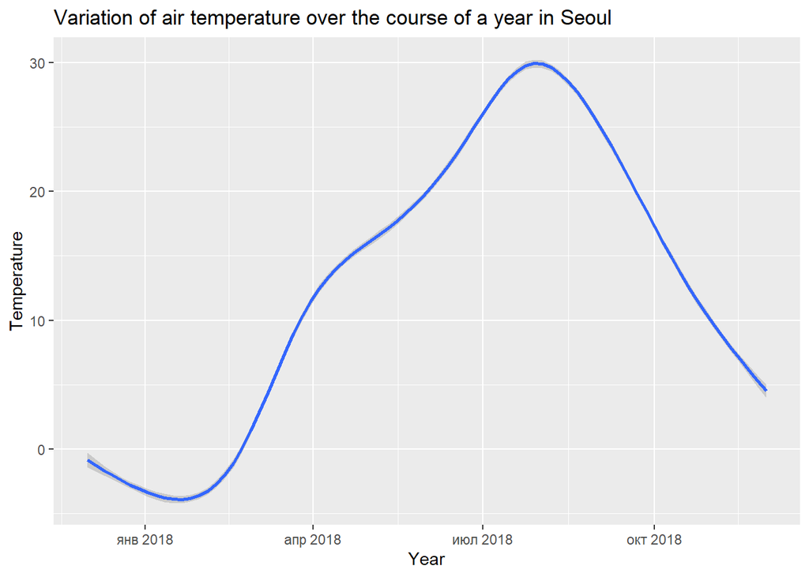

```r
ggplot(BikeSeoul, aes(x = Date, y = Temperature)) +
  geom_smooth() +
  labs(x = 'Year', y = 'Temperature', title = 'Variation of air temperature over the course of a year in Seoul')
```

### In Seoul the temperature varies over the course of a year. The temperature decreases in winter and autumn and increases in spring and summer.

### Variation of temperature over the course of a year in Washington.

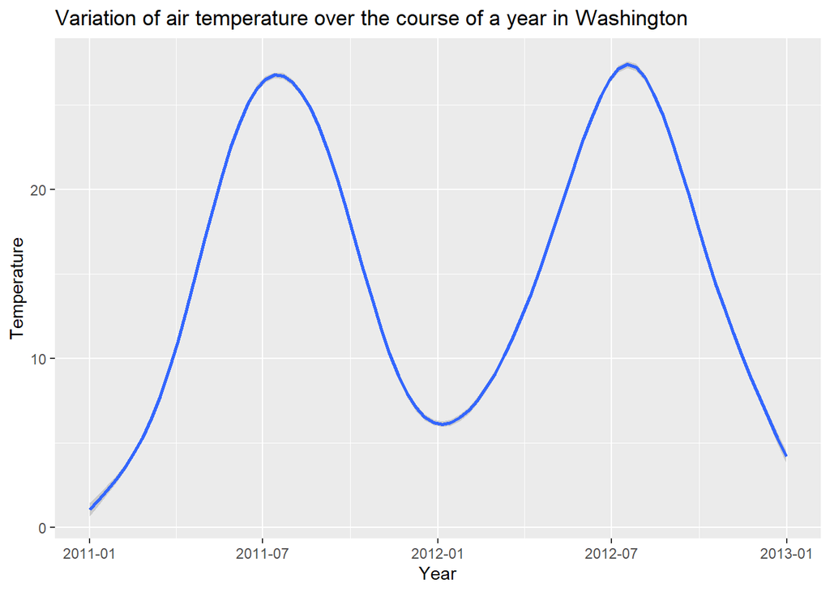

```r
ggplot(BikeWashingtonDC, aes(x = Date, y = Temperature)) +
  geom_smooth() +
  labs(x = 'Year', y = 'Temperature', title = 'Variation of air temperature over the course of a year in Washington')
```

### In Washington the temperature varies over the course of a year. The temperature decreases in winter and increases in summer.

### Correlation between seasons and the average number of rented bikes in Seoul.

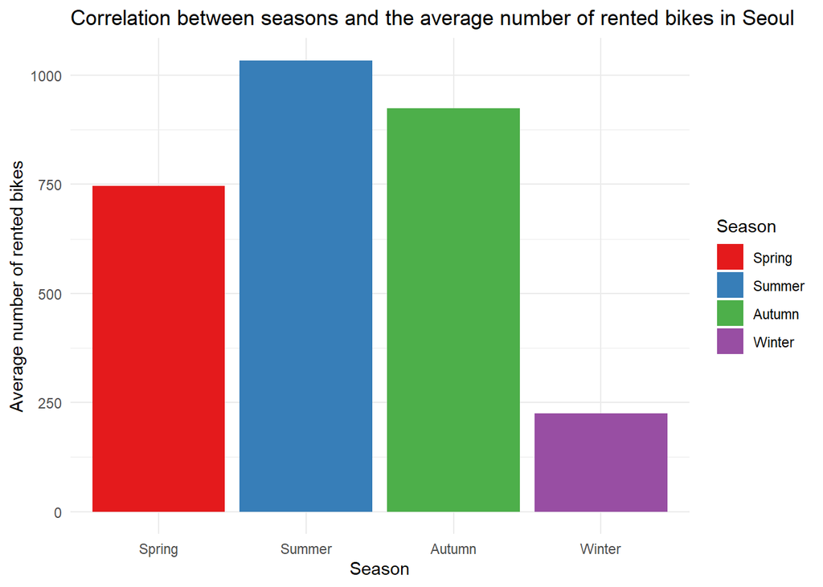

```r
library(dplyr)

# Transforming the data
seasonbikes_seoul <- transform(BikeSeoul, Date = as.Date(Date))
seasonbikes_seoul <- aggregate(Count ~ Season, data = seasonbikes_seoul, FUN = mean, na.rm = TRUE)

# Creating the bar plot for Seoul
ggplot(seasonbikes_seoul, aes(x = Season, y = Count, fill = Season)) +
  geom_col() +
  xlab("Season") +
  ylab("Average number of rented bikes") +
  ggtitle("Correlation between seasons and the average number of rented bikes in Seoul") +
  theme_minimal() +
  scale_fill_brewer(palette = "Set1")
```

### Seasons influence the number of bikes rented in Seoul. People prefer renting bikes in summer and there is a decrease in renting number of bikes in winter.

### Correlation between seasons and the average number of rented bikes in Washington.

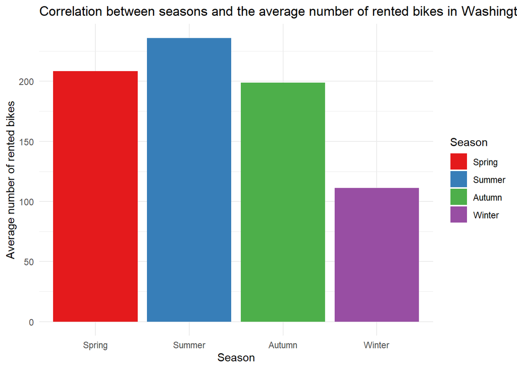

```r
seasonbikes_washington <- transform(BikeWashingtonDC, Date = as.Date(Date))
seasonbikes_washington <- aggregate(Count ~ Season, data = seasonbikes_washington, FUN = mean, na.rm = TRUE)

# Creating the bar plot for Washington
ggplot(seasonbikes_washington, aes(x = Season, y = Count, fill = Season)) +
  geom_col() +
  xlab("Season") +
  ylab("Average number of rented bikes") +
  ggtitle("Correlation between seasons and the average number of rented bikes in Washington") +
  theme_minimal() +
  scale_fill_brewer(palette = "Set1")
```

### Seasons influence the number of bikes rented in Washington. People prefer renting bikes in summer and there is a decrease in renting number of bikes in winter.

### Correlation between holidays and the demand for rented bikes in Seoul.

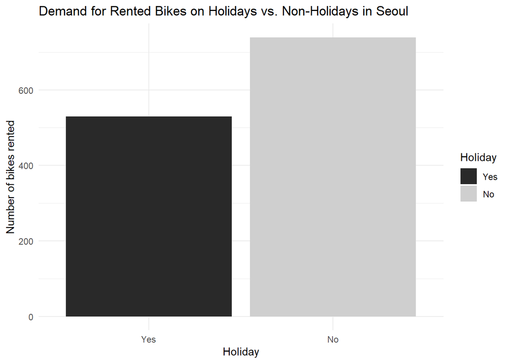

```r
# Calculating the average demand for rented bikes on holidays and non-holidays in Seoul.
average_demandS <- BikeSeoul %>%
  group_by(Holiday) %>%
  summarize(avg_demandS = mean(Count, na.rm = TRUE))

# Creating a bar plot
ggplot(average_demandS, aes(x = Holiday, y = avg_demandS, fill = Holiday)) +
  geom_bar(stat = "identity") +
  labs(x = "Holiday", y = "Number of bikes rented", title = "Demand for Rented Bikes on Holidays vs. Non-Holidays in Seoul") +
  scale_fill_manual(values = c("Yes" = "gray16", "No" = "gray81")) +
  theme_minimal()
```

### In Seoul people tend to rent bikes less often over Holdays.

### Correlation between holidays and the demand for rented bikes in Washington.

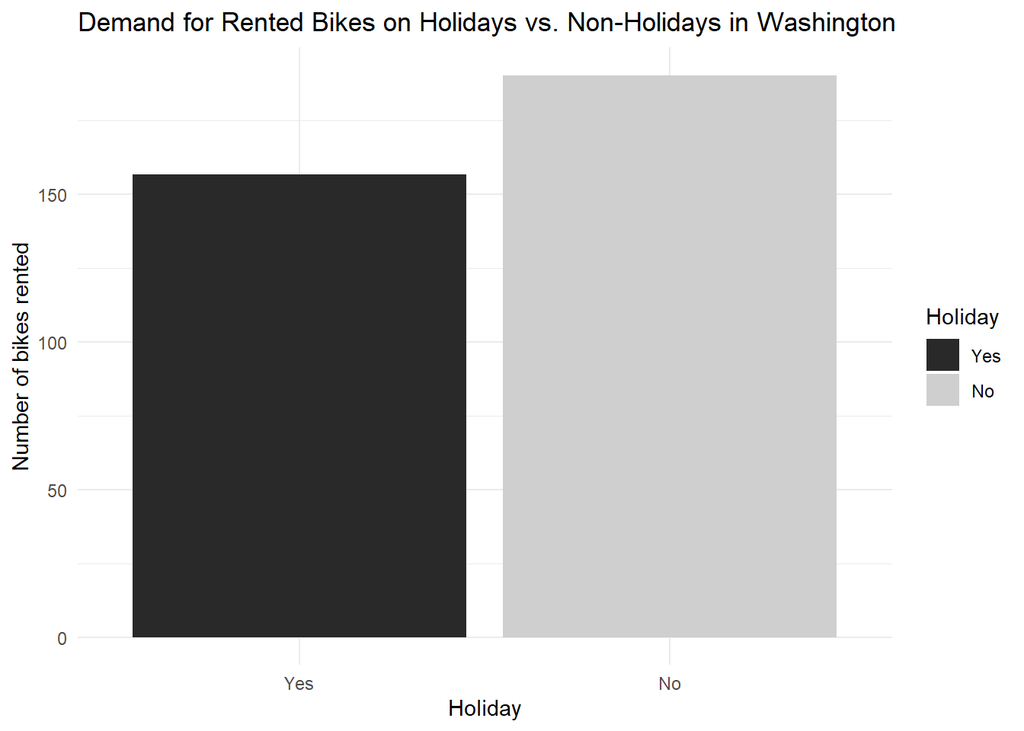

```r
# Calculating the average demand for rented bikes on holidays and non-holidays in Washington.

average_demandW <- BikeWashingtonDC %>%
  group_by(Holiday) %>%
  summarize(avg_demandW = mean(Count, na.rm = TRUE))

# Creating a bar plot
ggplot(average_demandW, aes(x = Holiday, y = avg_demandW, fill = Holiday)) +
  geom_bar(stat = "identity") +
  labs(x = "Holiday", y = "Number of bikes rented", title = "Demand for Rented Bikes on Holidays vs. Non-Holidays in Washington") +
  scale_fill_manual(values = c("Yes" = "gray16", "No" = "gray81")) +
  theme_minimal()
```

### In Washington people tend to rent bikes less often over Holdays.

### Correlation between the time of day and the demand for rented bikes in Seoul.

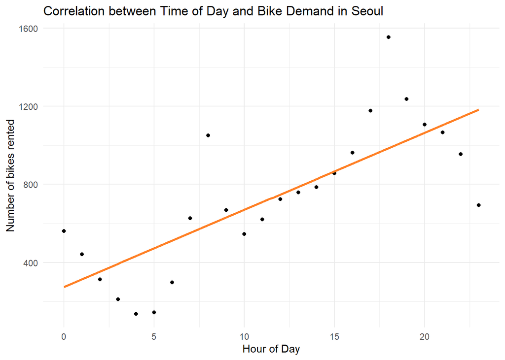

```r
# Calculating the correlation between time of day (hour) and demand
timebike_seoul <- BikeSeoul %>%
  group_by(Hour) %>%
  summarize(avg_demandSS = mean(Count, na.rm = TRUE))

# Create a scatter plot
ggplot(timebike_seoul, aes(x = Hour, y = avg_demandSS)) +
  geom_point() +
  geom_smooth(method = "lm", se = FALSE, color = "chocolate1") +
  labs(x = "Hour of Day", y = "Number of bikes rented", title = "Correlation between Time of Day and Bike Demand in Seoul") +
  theme_minimal()
```

### In Seoul people prefer renting bikes in the evenings.

[figure not shown]

```r
timebike_washington <- BikeSeoul %>%
  group_by(Hour) %>%
  summarize(avg_demandWW = mean(Count, na.rm = TRUE))

# Create a scatter plot
ggplot(timebike_washington, aes(x = Hour, y = avg_demandWW)) +
  geom_point() +
  geom_smooth(method = "lm", se = FALSE, color = "chocolate1") +
  labs(x = "Hour of Day", y = "Number of bikes rented", title = "Correlation between Time of Day and Bike Demand in Washington") +
  theme_minimal()
```

### Correlation between bike demand and the three meteorological variables (air temperature, wind speed and humidity) in Seoul.

```r
# Calculating the correlations
bikemeteo_seoul <- BikeSeoul %>%
  select(Count, Temperature, WindSpeed, Humidity) %>%
  cor()
```

### Creating correlation plots - individual scatter plots with regression lines

###Plot for Temperature

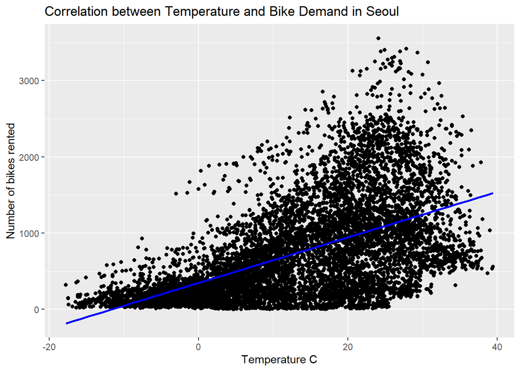

```r
ggplot(BikeSeoul, aes(x = Temperature, y = Count)) +
  geom_point() +
  geom_smooth(method = "lm", se = FALSE, color = "blue") +
  labs(x = 'Temperature C', y = 'Number of bikes rented', title = "Correlation between Temperature and Bike Demand in Seoul")
```

### When it is cold (below 0) or hot (+30 and higher) people in Seoul do not prefer renting bikes.

### Plot for Wind Speed

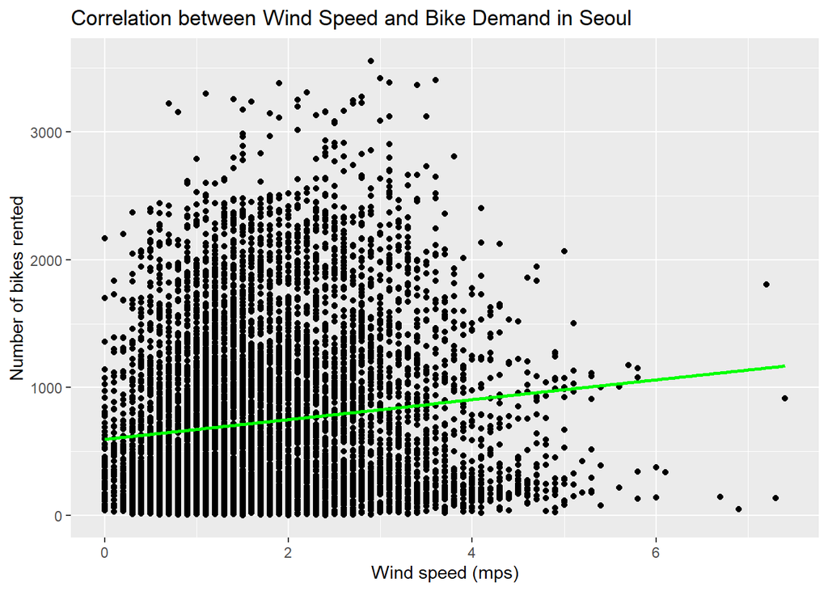

```r
ggplot(BikeSeoul, aes(x = WindSpeed, y = Count)) +
  geom_point() +
  geom_smooth(method = "lm", se = FALSE, color = "green") +
  labs(x ='Wind speed (mps)', y = 'Number of bikes rented',  title = "Correlation between Wind Speed and Bike Demand in Seoul")
```

### Plot for Humidity

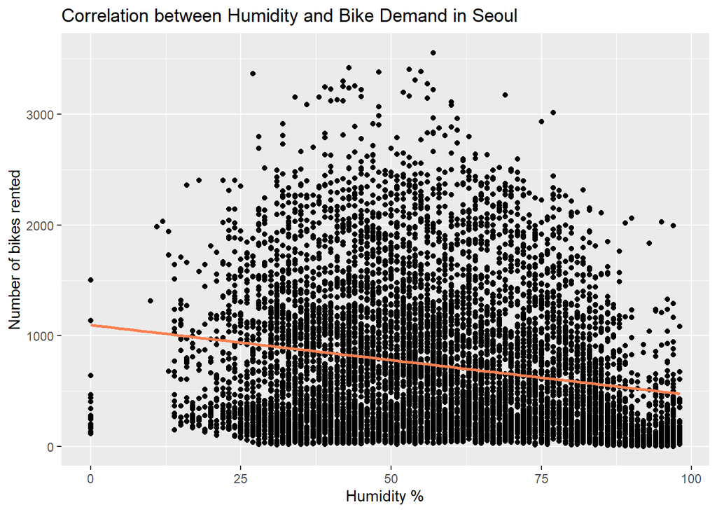

```r
ggplot(BikeSeoul, aes(x = Humidity, y = Count)) +
  geom_point() +
  geom_smooth(method = "lm", se = FALSE, color = "coral") +
  labs(x ='Humidity %', y = 'Number of bikes rented', title = "Correlation between Humidity and Bike Demand in Seoul")
```

### Correlation between bike demand and the three meteorological variables (air temperature, wind speed and humidity) in Washington.

```r
bikemeteo_washington <- BikeWashingtonDC %>%
  select(Count, Temperature, WindSpeed, Humidity) %>%
  cor()
```

### Plot for Temperature

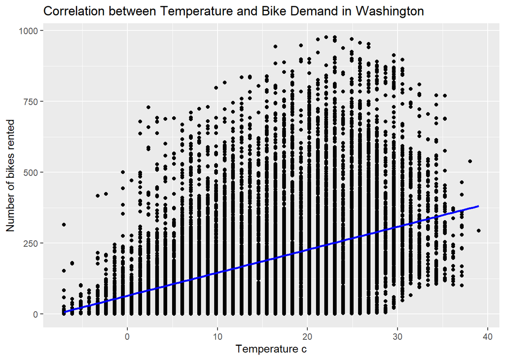

```r
ggplot(BikeWashingtonDC, aes(x = Temperature, y = Count)) +
  geom_point() +
  geom_smooth(method = "lm", se = FALSE, color = "blue") +
  labs(x = 'Temperature c', y = 'Number of bikes rented',  title = "Correlation between Temperature and Bike Demand in Washington")
```

### When it is cold (below 0) or hot (+30 and higher) people in Washington do not prefer renting bikes. ### Plot for Wind Speed

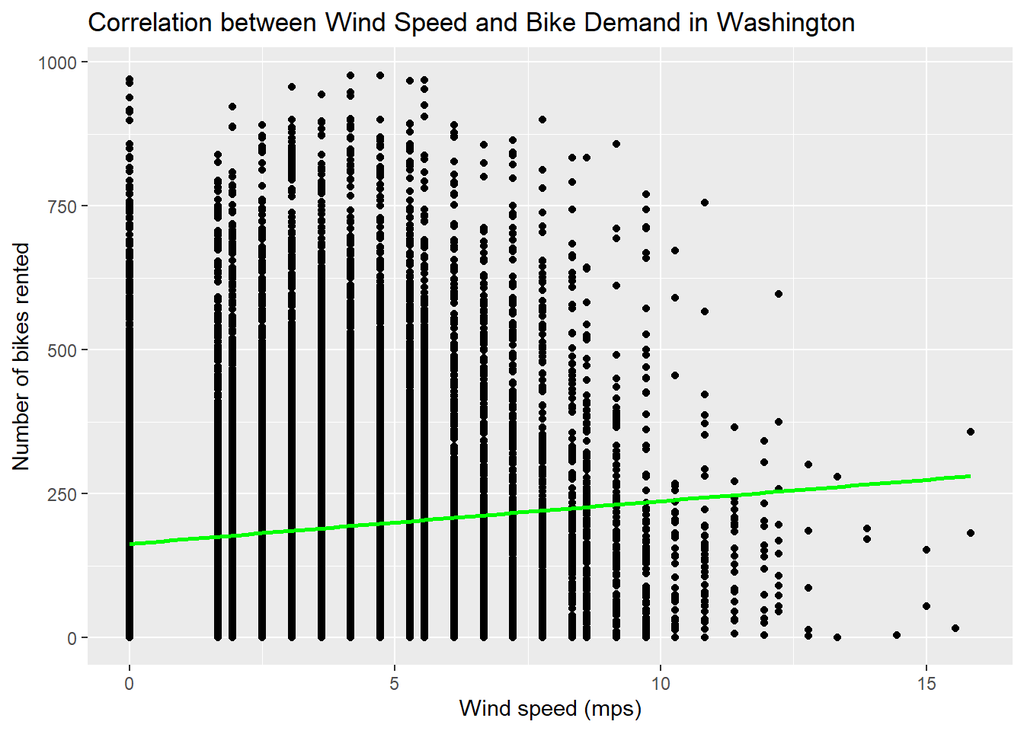

```r
ggplot(BikeWashingtonDC, aes(x = WindSpeed, y = Count)) +
  geom_point() +
  geom_smooth(method = "lm", se = FALSE, color = "green") +
  labs(x = 'Wind speed (mps)', y = 'Number of bikes rented', title = "Correlation between Wind Speed and Bike Demand in Washington")
```

### Plot for Humidity

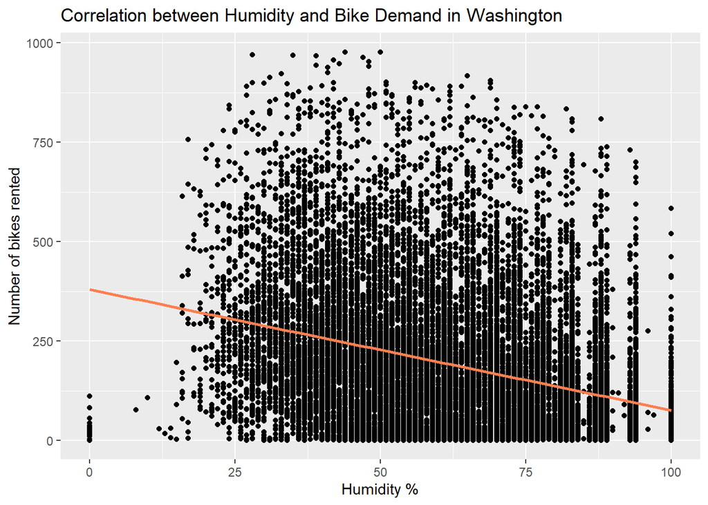

```r
ggplot(BikeWashingtonDC, aes(x = Humidity, y = Count)) +
  geom_point() +
  geom_smooth(method = "lm", se = FALSE, color = "coral") +
  labs(x = 'Humidity %', y = 'Number of bikes rented', title = "Correlation between Humidity and Bike Demand in Washington")
```

## Statistical Modelling

### Fitting a linear model with log count as outcome and season, air temperature, humidity, and wind speed as predictors

### Defining the linear model for Seoul

```r
seoul_model <- lm(log(Count) ~ Season + Temperature + Humidity + WindSpeed, data = BikeSeoul)
```

### Defining the linear model for Washington

```r
washington_model <- lm(log(Count) ~ Season + Temperature + Humidity + WindSpeed, data = BikeWashingtonDC)
```

```r
# Summary for the Seoul model
summary(seoul_model)
```

```
##
## Call:
## lm(formula = log(Count) ~ Season + Temperature + Humidity + WindSpeed,
##     data = BikeSeoul)
##
## Residuals:
##     Min      1Q  Median      3Q     Max
## -5.1073 -0.4281  0.0812  0.5493  2.4352
##
## Coefficients:
##                Estimate Std. Error t value Pr(>|t|)
## (Intercept)   6.7336965  0.0467062 144.171  < 2e-16 ***
## SeasonSummer  0.0036038  0.0327843   0.110  0.91247
## SeasonAutumn  0.3733211  0.0261578  14.272  < 2e-16 ***
## SeasonWinter -0.3830362  0.0349918 -10.946  < 2e-16 ***
## Temperature   0.0492700  0.0015053  32.732  < 2e-16 ***
## Humidity     -0.0224974  0.0004844 -46.441  < 2e-16 ***
## WindSpeed     0.0253809  0.0093544   2.713  0.00668 **
## ---
## Signif. codes:  0 '***' 0.001 '**' 0.01 '*' 0.05 '.' 0.1 ' ' 1
##
## Residual standard error: 0.8276 on 8458 degrees of freedom
## Multiple R-squared:  0.4941, Adjusted R-squared:  0.4937
## F-statistic:  1377 on 6 and 8458 DF,  p-value: < 2.2e-16
```

```r
# Summary for the Washington DC model
summary(washington_model)
```

```
##
## Call:
## lm(formula = log(Count) ~ Season + Temperature + Humidity + WindSpeed,
##     data = BikeWashingtonDC)
##
## Residuals:
##     Min      1Q  Median      3Q     Max
## -5.4834 -0.6069  0.2458  0.8440  3.5203
##
## Coefficients:
##                Estimate Std. Error t value Pr(>|t|)
## (Intercept)   4.6264010  0.0576892  80.195  < 2e-16 ***
## SeasonSummer -0.3651680  0.0300276 -12.161  < 2e-16 ***
## SeasonAutumn  0.5361839  0.0289332  18.532  < 2e-16 ***
## SeasonWinter  0.1046103  0.0341346   3.065  0.00218 **
## Temperature   0.0797914  0.0017401  45.856  < 2e-16 ***
## Humidity     -0.0233425  0.0005317 -43.901  < 2e-16 ***
## WindSpeed     0.0245022  0.0044358   5.524 3.37e-08 ***
## ---
## Signif. codes:  0 '***' 0.001 '**' 0.01 '*' 0.05 '.' 0.1 ' ' 1
##
## Residual standard error: 1.263 on 17372 degrees of freedom
## Multiple R-squared:  0.278,  Adjusted R-squared:  0.2777
## F-statistic:  1115 on 6 and 17372 DF,  p-value: < 2.2e-16
```

### Displaying the 97% confidence intervals for the estimated regression coefficients of the Seoul dataset

```r
# Define the confidence interval for Seoul
seoul_confidence <- confint(seoul_model, level = 0.97) # level is used to indicate the confidence interval, with 0.97 being a 97% confidence interval
seoul_confidence
```

```
##                     1.5 %      98.5 %
## (Intercept)   6.632322686  6.83507030
## SeasonSummer -0.067553139  0.07476072
## SeasonAutumn  0.316546593  0.43009553
## SeasonWinter -0.458984431 -0.30708797
## Temperature   0.046002904  0.05253719
## Humidity     -0.023548780 -0.02144592
## WindSpeed     0.005077663  0.04568421
```

### Displaying the 97% confidence intervals for the estimated regression coefficients of the Washington dataset

```r
#Define the confidence interval for Washingtgon DC
washington_confidence <- confint(washington_model, level = 0.97)
washington_confidence
```

```
##                    1.5 %      98.5 %
## (Intercept)   4.50119998  4.75160198
## SeasonSummer -0.43033590 -0.30000019
## SeasonAutumn  0.47339115  0.59897666
## SeasonWinter  0.03052896  0.17869159
## Temperature   0.07601506  0.08356781
## Humidity     -0.02449639 -0.02218851
## WindSpeed     0.01487540  0.03412904
```

### Providing a 90% prediction interval

```r
# Create a new data frame with the prediction values input

prediction_data <- data.frame(
  Season = "Winter",
  Temperature = 0,
  WindSpeed = 0.5,
  Humidity = 20
)
```

### Using the `predict` function to make predictions with a 90% prediction interval for Seoul data

```r
## Use the `predict` function to make predictions with a 90% prediction interval

# Seoul function
seoul_prediction <- predict(seoul_model, newdata = prediction_data, interval = "predict", level = 0.90)
seoul_prediction
```

```
##        fit    lwr      upr
## 1 5.913404 4.5512 7.275607
```

### Using the `predict` function to make predictions with a 90% prediction interval for Washington data

```r
# Washington function
washington_prediction <- predict(washington_model, newdata = prediction_data, interval = "predict", level = 0.90)
washington_prediction
```

```
##        fit      lwr      upr
## 1 4.276413 2.197947 6.354879
```